# missing data

Missing data are quite common in real datasets. This may be driven by a number of reasons including, data was not available, was not gathered, or coded incorrectly.

A number of predictive models require complete data. And, even among the predictive models that can function with less than complete data, missing data can only exist in predictors not the response variable. Before we proceed to find a solution to missing data let us examine the reasons for it. The reasons may be broadly categorized as 1. Random: The cause of missing data may be completely random. Survey respondents may neglect to answer certain questions by chance. Person coding data may commit a data entry error. 2. Data deficiency: This may be a missing component of a predictor. Consider a survey containing the alternatives male and female for a question on gender. Those not conforming to a particular gender may not respond.  
3. Specific Causes: There are situations where missing data can be clearly attributed to a cause. Survey respondents may refuse to respond to questions on politically sensitive issues such as abortion and right to bear arms. In clinical studies where patients are measured periodically over time, a patient may drop off due to an adverse side effect.

# Examine Missing Data

The pattern of missing data is likely to shed light on the reasons behind it. For small and medium datasets, it is possible to visualize missing data in a chart such as a heatmap. When the dataset has a large number of variables or observations, the data must be suitably condensed before visualizing.

To illustrate, let us create some missing data in the `mtcars` dataset

```r
mtcars_missing = mtcars
for(i in 1:35){
  set.seed(i)
  x = sample(1:nrow(mtcars), 1)
  y = sample(1:ncol(mtcars), 1)
  mtcars_missing[x, y] = NA
}
mtcars_missing
```

|  | mpg | cyl | disp | hp | drat | wt | qsec | vs | am | gear | carb |
| --- | --- | --- | --- | --- | --- | --- | --- | --- | --- | --- | --- |
| Mazda RX4 | 21.0 | 6 | 160.0 | 110 | 3.90 | 2.620 | 16.46 | 0 | 1 | 4 | NA |
| Mazda RX4 Wag | 21.0 | 6 | 160.0 | 110 | 3.90 | 2.875 | 17.02 | 0 | 1 | NA | NA |
| Datsun 710 | 22.8 | 4 | 108.0 | 93 | 3.85 | 2.320 | 18.61 | 1 | 1 | 4 | 1 |
| Hornet 4 Drive | 21.4 | 6 | 258.0 | 110 | 3.08 | 3.215 | 19.44 | 1 | 0 | 3 | 1 |
| Hornet Sportabout | 18.7 | NA | 360.0 | 175 | 3.15 | 3.440 | 17.02 | 0 | 0 | NA | 2 |
| Valiant | 18.1 | 6 | 225.0 | 105 | 2.76 | 3.460 | 20.22 | 1 | NA | 3 | NA |
| Duster 360 | 14.3 | 8 | NA | 245 | 3.21 | 3.570 | 15.84 | NA | 0 | 3 | 4 |
| Merc 240D | 24.4 | 4 | 146.7 | 62 | 3.69 | 3.190 | 20.00 | 1 | 0 | 4 | 2 |
| Merc 230 | 22.8 | 4 | 140.8 | 95 | 3.92 | 3.150 | 22.90 | 1 | NA | 4 | 2 |
| Merc 280 | NA | NA | NA | 123 | 3.92 | NA | 18.30 | NA | 0 | 4 | 4 |

[output cut: 22 more lines]

When the dataset has a reasonable number of observations and variables, a simple method to visualize missing information is a heatmap. With library(ggplot2), `geom_tile` can be used to generate a simple heatmap.

We first classify all observations based on whether they are missing (0) or not (1)

```r
mtcars_missing_bi = mtcars_missing
mtcars_missing_bi[!is.na(mtcars_missing)] = 1
mtcars_missing_bi[is.na(mtcars_missing)] = 0
```

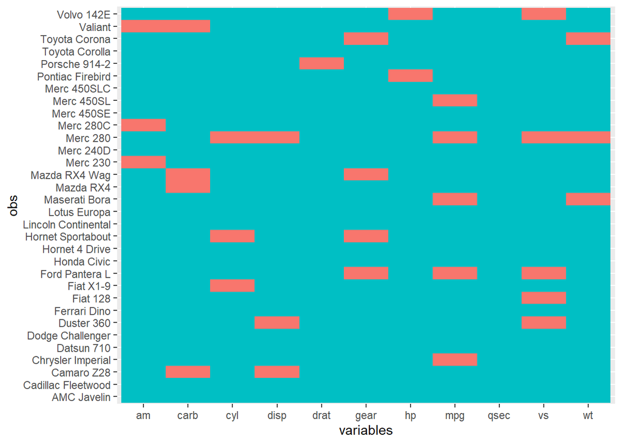

```r
library(tidyr); library(dplyr); library(ggplot2)
mtcars_missing_bi %>%
  as_tibble()%>%
  mutate(obs = rownames(mtcars_missing_bi))%>%
  select(obs, everything())%>%
  pivot_longer(cols = 2:12, names_to = 'variables', values_to = 'values' )%>%
  ggplot(aes(variables, obs, fill= factor(values))) +
  geom_tile()+
  guides(fill=F)
```

Identifying patterns in a moderate sized heatmap can be challenging. To aid intepretation, `library(ComplexHeatMap)` groups variables and observations and represents the groups using a dendrogram. The author has a nice book on the bells and whistles of `ComplexHeatMap`.

`ComplexHeatMap` can be installed from Bioconductor

```r
# install.packages('BiocManager')
# BiocManager::install('ComplexHeatmap')
```

Alternatively, the most recent version can be obtained from github

```r
#library(devtools)
#install_github("jokergoo/ComplexHeatmap")
```

The following heatmap groups the tiles to make it easier to spot patterns in missing data.

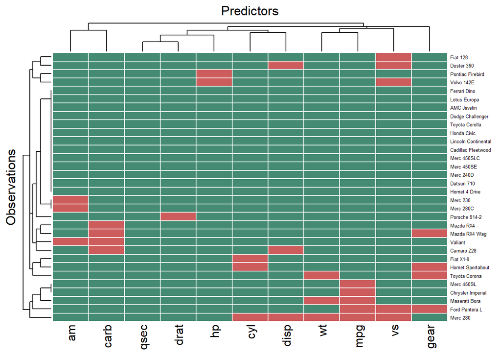

```r
library(ComplexHeatmap)
library(circlize)
Heatmap(mtcars_missing_bi,
        rect_gp = gpar(col = "white", lwd = 1),
        name = 'Seeing What is Missing',
        column_title = 'Predictors',
        row_title = 'Observations',
        col = circlize::colorRamp2(c(0,1),c('indianred','aquamarine4')),
        show_heatmap_legend = F,
        row_names_gp = gpar(fontsize = 5))
```

For larger datasets, the data needs to be reduced (using a technique such as principal components analysis) before constructing a heatmap. Another valuable tool for examining the nature and degree of missing data are numerical summaries. For the `mtcars_missing`, for each variable, here are the (a) number of missing values

```r
apply(mtcars_missing,
      MARGIN = 2,
      FUN = function(x) sum(is.na(x)))
```

```
##  mpg  cyl disp   hp drat   wt qsec   vs   am gear carb
##    5    3    3    2    1    3    0    5    3    4    4
```

2. percent of missing values

```r
apply(mtcars_missing,
      MARGIN = 2,
      FUN = function(x) 100*sum(is.na(x))/(sum(is.na(x))+ sum(!is.na(x))))
```

```
##    mpg    cyl   disp     hp   drat     wt   qsec     vs     am   gear   carb
## 15.625  9.375  9.375  6.250  3.125  9.375  0.000 15.625  9.375 12.500 12.500
```

# Solutions

Before we examine solutions, it is worth noting that while many popular predictive models such as linear regression, penalized regression models, support vector machines and neural networks cannot tolerate any amount of missing values, there are a few predictive models such as classification and regression trees and other tree-based models that can handle incomplete data.

For the vast majority of predictive models and also a number unsupervised learning methods, missing values need to be addressed. There are three broad categories of solutions, (a) delete (or ignore) missing values, (b) encode missing data, (c) impute.

## Delete

By far, the simplest solution to missing data is remove them either by deleting or ignoring. The most common approach is to conduct listwise deletion wherein the entire row is deleted if even a single element is missing. In `mtcars_missing`, the following rows are missing at least one value.

```r
apply(mtcars_missing, MARGIN = 1, function(x) any(is.na(x)))
```

```
##           Mazda RX4       Mazda RX4 Wag          Datsun 710      Hornet 4 Drive
##                TRUE                TRUE               FALSE               FALSE
##   Hornet Sportabout             Valiant          Duster 360           Merc 240D
##                TRUE                TRUE                TRUE               FALSE
##            Merc 230            Merc 280           Merc 280C          Merc 450SE
##                TRUE                TRUE                TRUE               FALSE
##          Merc 450SL         Merc 450SLC  Cadillac Fleetwood Lincoln Continental
##                TRUE               FALSE               FALSE               FALSE
##   Chrysler Imperial            Fiat 128         Honda Civic      Toyota Corolla
##                TRUE                TRUE               FALSE               FALSE
##       Toyota Corona    Dodge Challenger         AMC Javelin          Camaro Z28
##                TRUE               FALSE               FALSE                TRUE
##    Pontiac Firebird           Fiat X1-9       Porsche 914-2        Lotus Europa
##                TRUE                TRUE                TRUE               FALSE
##      Ford Pantera L        Ferrari Dino       Maserati Bora          Volvo 142E
##                TRUE               FALSE                TRUE                TRUE
```

Removing them leaves only 13 of the 32 rows in `mtcars_missing`!

```r
mtcars_missing[!apply(mtcars_missing, MARGIN = 1, function(x) any(is.na(x))),]
```

|  | mpg | cyl | disp | hp | drat | wt | qsec | vs | am | gear | carb |
| --- | --- | --- | --- | --- | --- | --- | --- | --- | --- | --- | --- |
| Datsun 710 | 22.8 | 4 | 108.0 | 93 | 3.85 | 2.320 | 18.61 | 1 | 1 | 4 | 1 |
| Hornet 4 Drive | 21.4 | 6 | 258.0 | 110 | 3.08 | 3.215 | 19.44 | 1 | 0 | 3 | 1 |
| Merc 240D | 24.4 | 4 | 146.7 | 62 | 3.69 | 3.190 | 20.00 | 1 | 0 | 4 | 2 |
| Merc 450SE | 16.4 | 8 | 275.8 | 180 | 3.07 | 4.070 | 17.40 | 0 | 0 | 3 | 3 |
| Merc 450SLC | 15.2 | 8 | 275.8 | 180 | 3.07 | 3.780 | 18.00 | 0 | 0 | 3 | 3 |
| Cadillac Fleetwood | 10.4 | 8 | 472.0 | 205 | 2.93 | 5.250 | 17.98 | 0 | 0 | 3 | 4 |
| Lincoln Continental | 10.4 | 8 | 460.0 | 215 | 3.00 | 5.424 | 17.82 | 0 | 0 | 3 | 4 |
| Honda Civic | 30.4 | 4 | 75.7 | 52 | 4.93 | 1.615 | 18.52 | 1 | 1 | 4 | 2 |
| Toyota Corolla | 33.9 | 4 | 71.1 | 65 | 4.22 | 1.835 | 19.90 | 1 | 1 | 4 | 1 |
| Dodge Challenger | 15.5 | 8 | 318.0 | 150 | 2.76 | 3.520 | 16.87 | 0 | 0 | 3 | 2 |

[output cut: 3 more lines]

Many predictive modeling functions (e.g., `lm`) will automatically conduct listwise deletion. Note in the following output, “19 observations deleted due to missingness”

```r
summary(lm(mpg~.,mtcars_missing))
```

```
##
## Call:
## lm(formula = mpg ~ ., data = mtcars_missing)
##
## Residuals:
##          Datsun 710      Hornet 4 Drive           Merc 240D          Merc 450SE
##          -1.108e+00          -7.352e-01          -6.661e-16           9.495e-01
##         Merc 450SLC  Cadillac Fleetwood Lincoln Continental         Honda Civic
##           2.421e-01           2.706e-01           2.980e-02           4.134e-01
##      Toyota Corolla    Dodge Challenger         AMC Javelin        Lotus Europa
##           6.943e-01           1.810e+00          -2.566e+00           7.352e-01
##        Ferrari Dino
##          -7.352e-01
##
## Coefficients:
##               Estimate Std. Error t value Pr(>|t|)
## (Intercept) -280.98109  166.37953  -1.689    0.233
## cyl           19.61883   13.19206   1.487    0.275
## disp          -0.04405    0.04758  -0.926    0.452
## hp            -0.17579    0.16670  -1.055    0.402
## drat           7.01319    5.20404   1.348    0.310
## wt             8.77079   11.02143   0.796    0.510
## qsec           3.41823    2.04149   1.674    0.236
## vs            26.01966   19.08962   1.363    0.306
## am            10.87792   10.71197   1.015    0.417
## gear          25.82345   15.41268   1.675    0.236
## carb          -3.63447    3.04106  -1.195    0.355
##
## Residual standard error: 2.683 on 2 degrees of freedom
##   (19 observations deleted due to missingness)
## Multiple R-squared:  0.9794, Adjusted R-squared:  0.8765
## F-statistic: 9.518 on 10 and 2 DF,  p-value: 0.09876
```

```r
sum(is.na(mtcars_missing))/nrow(mtcars)*ncol(mtcars) # Percent missing values
```

```
## [1] 11.34375
```

```r
100* nrow(mtcars_missing[apply(mtcars_missing, MARGIN = 1, function(x) any(is.na(x))),])/nrow(mtcars_missing) # Percent rows deleted
```

```
## [1] 59.375
```

A third and perhaps most important consideration is the likelihood of introducing bias into the model. Consider a clinical study where half the respondents receive the current standard care of treatment while the other half receive the new treatment. The new treatment may induce adverse effects causing patients to drop out of the study. Such missing data is clearly not random and deleting them is bound to bias results.

## Encode Missing Data

Missing data may represent information. In a survey that only contains two alternatives for gender, those not conforming to either gender may skip the question. In this case, non-response may contain information valuable gender orientation. As another example, survey respondents may refuse to respond to questions on politically sensitive issues such as abortion and right to bear arms. Here again, non-response may contain useful information.

In a categorical variable, missing data may be encoded as another level. Consider the following example.

```r
set.seed(61710)
gender = sample(c('Male','Female',NA),10,T)
gender
```

```
##  [1] NA       "Female" "Male"   NA       "Male"   "Male"   "Female" "Male"
##  [9] "Female" "Female"
```

```r
gender_encoded = gender
gender_encoded[is.na(gender)] = 'Did Not Respond'
gender_encoded
```

```
##  [1] "Did Not Respond" "Female"          "Male"            "Did Not Respond"
##  [5] "Male"            "Male"            "Female"          "Male"
##  [9] "Female"          "Female"
```

Missing data in a continuous variable may be represented using a dummy variable.

```r
mtcars_missing_encoded = mtcars_missing
mtcars_missing_encoded %>%
  mutate(cyl_missing = ifelse(is.na(mtcars_missing_encoded$cyl),0,1))%>%
  select(mpg, cyl, cyl_missing, everything())
```

|  | mpg | cyl | cyl_missing | disp | hp | drat | wt | qsec | vs | am | gear | carb |
| --- | --- | --- | --- | --- | --- | --- | --- | --- | --- | --- | --- | --- |
| Mazda RX4 | 21.0 | 6 | 1 | 160.0 | 110 | 3.90 | 2.620 | 16.46 | 0 | 1 | 4 | NA |
| Mazda RX4 Wag | 21.0 | 6 | 1 | 160.0 | 110 | 3.90 | 2.875 | 17.02 | 0 | 1 | NA | NA |
| Datsun 710 | 22.8 | 4 | 1 | 108.0 | 93 | 3.85 | 2.320 | 18.61 | 1 | 1 | 4 | 1 |
| Hornet 4 Drive | 21.4 | 6 | 1 | 258.0 | 110 | 3.08 | 3.215 | 19.44 | 1 | 0 | 3 | 1 |
| Hornet Sportabout | 18.7 | NA | 0 | 360.0 | 175 | 3.15 | 3.440 | 17.02 | 0 | 0 | NA | 2 |
| Valiant | 18.1 | 6 | 1 | 225.0 | 105 | 2.76 | 3.460 | 20.22 | 1 | NA | 3 | NA |
| Duster 360 | 14.3 | 8 | 1 | NA | 245 | 3.21 | 3.570 | 15.84 | NA | 0 | 3 | 4 |
| Merc 240D | 24.4 | 4 | 1 | 146.7 | 62 | 3.69 | 3.190 | 20.00 | 1 | 0 | 4 | 2 |
| Merc 230 | 22.8 | 4 | 1 | 140.8 | 95 | 3.92 | 3.150 | 22.90 | 1 | NA | 4 | 2 |
| Merc 280 | NA | NA | 0 | NA | 123 | 3.92 | NA | 18.30 | NA | 0 | 4 | 4 |

[output cut: 22 more lines]

## Impute

In imputation, information and relationships among non-missing predictors is used to estimate missing values. Approaches to imputation differ based on whether they are designed for inferences or prediction. Our focus is going to be on the latter, so the quality of an imputation procedure will be judged by its ability to accurately predict missing values.

It is important to remember that imputed values are merely estimates of the true value for missing data. Thus, one must limit how much missing data is imputed. While there isn’t a universal rule on how much data can be imputed, no more than 20% for a variable may be a good thumb rule to use.

Imputation must occur prior to other steps in data preparation.

There are a number of methods available for imputing missing data (e.g., predictive mean matching, k-nearest neighbors, trees and tree-based methods) and a number of R package that implement these (e.g., `mice`, `caret`)

### mice

mice() implements a number of imputation methods. This illustration uses the default, which for numeric data is predictive mean matching. For more information, see [author’s website](https://stefvanbuuren.github.io/Winnipeg/). In version 3.12.0, mice library implemented a new matchindex C function that makes predictive mean matching 50 to 600 times faster, however this affects reproducibility of the algorithm. Read more about the update (here)[https://cran.r-project.org/web/packages/mice/news/news.html]. (If you wish to reproduce the behavior of the previous version of `mice`, include use.matcher=T in the mice function). Finally, `tidyr` has an identically named `complete` function. To prevent conflicts, it is best to include the package reference, mice::complete(…)

```r
library(mice)
mtcars_mice = mice::complete(mice(mtcars_missing,seed = 617))
head(mtcars_mice)
```

|  | mpg | cyl | disp | hp | drat | wt | qsec | vs | am | gear | carb |
| --- | --- | --- | --- | --- | --- | --- | --- | --- | --- | --- | --- |
| Mazda RX4 | 21.0 | 6 | 160 | 110 | 3.90 | 2.620 | 16.46 | 0 | 1 | 4 | 3 |
| Mazda RX4 Wag | 21.0 | 6 | 160 | 110 | 3.90 | 2.875 | 17.02 | 0 | 1 | 4 | 4 |
| Datsun 710 | 22.8 | 4 | 108 | 93 | 3.85 | 2.320 | 18.61 | 1 | 1 | 4 | 1 |
| Hornet 4 Drive | 21.4 | 6 | 258 | 110 | 3.08 | 3.215 | 19.44 | 1 | 0 | 3 | 1 |
| Hornet Sportabout | 18.7 | 8 | 360 | 175 | 3.15 | 3.440 | 17.02 | 0 | 0 | 3 | 2 |
| Valiant | 18.1 | 6 | 225 | 105 | 2.76 | 3.460 | 20.22 | 1 | 0 | 3 | 1 |

```r
library(mice)
mtcars_mice_rf = mice::complete(mice(mtcars_missing,method = 'rf',seed = 617))
head(mtcars_mice_rf)
```

|  | mpg | cyl | disp | hp | drat | wt | qsec | vs | am | gear | carb |
| --- | --- | --- | --- | --- | --- | --- | --- | --- | --- | --- | --- |
| Mazda RX4 | 21.0 | 6 | 160 | 110 | 3.90 | 2.620 | 16.46 | 0 | 1 | 4 | 2 |
| Mazda RX4 Wag | 21.0 | 6 | 160 | 110 | 3.90 | 2.875 | 17.02 | 0 | 1 | 5 | 1 |
| Datsun 710 | 22.8 | 4 | 108 | 93 | 3.85 | 2.320 | 18.61 | 1 | 1 | 4 | 1 |
| Hornet 4 Drive | 21.4 | 6 | 258 | 110 | 3.08 | 3.215 | 19.44 | 1 | 0 | 3 | 1 |
| Hornet Sportabout | 18.7 | 8 | 360 | 175 | 3.15 | 3.440 | 17.02 | 0 | 0 | 3 | 2 |
| Valiant | 18.1 | 6 | 225 | 105 | 2.76 | 3.460 | 20.22 | 1 | 0 | 3 | 1 |

### caret

caret is a full blown machine learning framework that contains a number of handy functions. preprocess() can be used for imputing, [among other things](http://topepo.github.io/caret/pre-processing.html). Here, we are using a bagImpute, which works by fitting a bagged tree model for each predictor (as a function of all the others). This method is quite accurate, but has much higher computational cost than say medianImpute.

```r
library(caret)
set.seed(617)
mtcars_caret = predict(preProcess(mtcars_missing,
                                  method = 'bagImpute'),
                       newdata = mtcars_missing)
head(mtcars_caret)
```

|  | mpg | cyl | disp | hp | drat | wt | qsec | vs | am | gear | carb |
| --- | --- | --- | --- | --- | --- | --- | --- | --- | --- | --- | --- |
| Mazda RX4 | 21.0 | 6.000000 | 160 | 110 | 3.90 | 2.620 | 16.46 | 0 | 1.0000000 | 4.000000 | 2.438462 |
| Mazda RX4 Wag | 21.0 | 6.000000 | 160 | 110 | 3.90 | 2.875 | 17.02 | 0 | 1.0000000 | 3.615385 | 2.438462 |
| Datsun 710 | 22.8 | 4.000000 | 108 | 93 | 3.85 | 2.320 | 18.61 | 1 | 1.0000000 | 4.000000 | 1.000000 |
| Hornet 4 Drive | 21.4 | 6.000000 | 258 | 110 | 3.08 | 3.215 | 19.44 | 1 | 0.0000000 | 3.000000 | 1.000000 |
| Hornet Sportabout | 18.7 | 6.246154 | 360 | 175 | 3.15 | 3.440 | 17.02 | 0 | 0.0000000 | 3.615385 | 2.000000 |
| Valiant | 18.1 | 6.000000 | 225 | 105 | 2.76 | 3.460 | 20.22 | 1 | 0.3538462 | 3.000000 | 2.438462 |

There are a number of imputation methods available but no single method is the best in every situation. Here is a comparison of the different imputation methods on the missing data.

```r
df = data.frame(true_values = mtcars[is.na(mtcars_missing)],
           mice_pmm = mtcars_mice[is.na(mtcars_missing)],
           mice_rf = mtcars_mice_rf[is.na(mtcars_missing)],
           caret_bagImpute = mtcars_caret[is.na(mtcars_missing)])
df
```

| true_values | mice_pmm | mice_rf | caret_bagImpute |
| --- | --- | --- | --- |
| 19.200 | 18.70 | 18.700 | 20.9530769 |
| 17.300 | 15.20 | 19.200 | 20.9530769 |
| 14.700 | 10.40 | 19.200 | 20.9530769 |
| 15.800 | 19.70 | 13.300 | 20.9530769 |
| 15.000 | 15.20 | 13.300 | 20.9530769 |
| 8.000 | 8.00 | 8.000 | 6.2461538 |
| 6.000 | 6.00 | 6.000 | 6.2461538 |
| 4.000 | 4.00 | 4.000 | 6.2461538 |
| 360.000 | 351.00 | 275.800 | 244.3669231 |
| 167.600 | 304.00 | 160.000 | 244.3669231 |

[output cut: 23 more lines]

```r
library(ggplot2); library(tidyr)
rownames(df)
```

```
##  [1] "1"  "2"  "3"  "4"  "5"  "6"  "7"  "8"  "9"  "10" "11" "12" "13" "14" "15"
## [16] "16" "17" "18" "19" "20" "21" "22" "23" "24" "25" "26" "27" "28" "29" "30"
## [31] "31" "32" "33"
```

[figure not shown]

```r
df %>%
  mutate(id = as.integer(rownames(df)))%>%
  select(id, everything())%>%
  pivot_longer(2:5,names_to = 'method',values_to ='values')%>%
  mutate(true_value = factor(ifelse(method == 'true_values',1,0),labels = c('True Value','Imputed Value')))%>%
  ggplot(aes(x = id, y=values, color=true_value, shape = method))+
  geom_point()+theme_bw()
```